# Quarantine Movie Club

Movie Picker for the Week

Dave Gruenewald

November 08, 2020

[figure not shown]

## Motivation

Individuals of varying (and possibly suspect) taste were asked to recommend and rank the watchability of movies from 1 (hard pass) to 10 (must watch now). Also I’m bored as shit, so let’s do this…

## IMDB Metascore Ratings

[figure not shown]

```r
imdb_df <-
  movie_v %>%
  map_dfr(imdbMovies) %>%
  as_tibble()

imdb_df %>%
  mutate(
    imdbVotes = parse_number(imdbVotes),
    Metascore = parse_number(Metascore),
    imdbRating = parse_number(imdbRating)
  ) %>%
  ggplot(
    aes(
      x = fct_reorder(Title, imdbRating, .desc = TRUE),
      y = imdbRating
    )
  ) +
  # geom_col()
  geom_col_pattern(
    aes(
      pattern_filename = I(Posterlink)),
    pattern_gravity = "North",
    pattern         = "image",
    pattern_scale   = 1,
    pattern_type    = 'fit',
    fill            = "#69b3a2",
    colour          = '#69b3a2'
  ) +
  dark_theme_gray(base_size = 16) +
  scale_x_discrete(
    guide = guide_axis(n.dodge = 2)
  ) +
  labs(x = NULL,
       y = "IMDB Rating") +
  theme(axis.title = element_text(colour = "#69b3a2"))
```

Now to see how close the QMC agrees…

## Responses

```r
movie_df %>%
  kable() %>%
  kable_styling(bootstrap_options = c("striped", "hover", "condensed", "responsive"),
                full_width = F)
```

| Timestamp | October Sky | Jerry Maguire | Bridesmaids | My Neighbor Totoro | Big | Finding Forrester |
| --- | --- | --- | --- | --- | --- | --- |
| 11/8/2020 15:38:19 | 10 | 9 | 8 | 7 | 6 | 7 |
| 11/8/2020 15:43:32 | 4 | 5 | 10 | 8 | 3 | 7 |
| 11/8/2020 15:46:48 | 5 | 10 | 1 | 8 | 9 | 4 |
| 11/8/2020 15:47:42 | 7 | 8 | 2 | 7 | 9 | 5 |
| 11/8/2020 16:30:39 | 10 | 8 | 5 | 5 | 6 | 10 |
| 11/8/2020 19:12:32 | 9 | 3 | 8 | 10 | 7 | 9 |

## Movies

### Overall Likeability

Which movies had the highest average score?

| movie | mean |
| --- | --- |
| My Neighbor Totoro | 7.500000 |
| October Sky | 7.500000 |
| Jerry Maguire | 7.166667 |
| Finding Forrester | 7.000000 |
| Big | 6.666667 |
| Bridesmaids | 5.666667 |

**My Neighbor Totoro** appears to be universally appreciated, while **Bridesmaids** is clearly foul.

### Other Voting Metrics

```r
vote <- movie_df %>%
  mutate(
    across(
      where(is.numeric),
      ~flip_convert(.x)
    )
  ) %>%
  as.data.frame() %>%
  column_to_rownames(var = "Timestamp") %>%
  as.matrix() %>%
  create_vote(xtype = 1)

approval <- approval_method(vote, n = 3)
borda <- borda_method(vote)
copeland <- cdc_copeland(vote)
dodgson <- cdc_dodgson(vote, dq_t = "t")

borda_df <- borda$other_info$count_min %>%
  data.frame() %>%
  rownames_to_column("Movie") %>%
  rename(Rank = 2) %>%
  arrange(Rank)

copeland_df <- copeland$other_info$copeland_score %>%
  data.frame() %>%
  rownames_to_column("Movie") %>%
  rename(Rank = 2) %>%
  arrange(desc(Rank))

dodgson_df <- dodgson$other_info$tideman %>%
  data.frame() %>%
  rownames_to_column("Movie") %>%
  rename(Rank = 2) %>%
  arrange(Rank)
```

#### Borda Method

> A voter’s 1st choice gets 1 point, the 2nd choice gets 2 points… The movie with the smallest total score wins. The function does not require voters to assign scores to all Movies, for NAs are automatically assigned the highest (worst) score. Duplicated values (two or more movies share the same score) are also allowed.

**Borda Winner:** October Sky, My Neighbor Totoro

```r
borda_df %>%
  kable() %>%
  kable_styling(bootstrap_options = c("striped", "hover", "condensed", "responsive"),
                full_width = F)
```

| Movie | Rank |
| --- | --- |
| October Sky | 21 |
| My Neighbor Totoro | 21 |
| Jerry Maguire | 23 |
| Finding Forrester | 24 |
| Big | 26 |
| Bridesmaids | 32 |

#### Copeland

> Movies enter into pairwise comparison. If the number of voters who prefer `Movie A` is larger than the number of voters who prefer `Movie B` , then `Movie A` wins `Movie B`, `Movie A` gets 1 point, and `Movie B` gets -1 point. If the numbers are equal, then both of them gets 0 point. Then, sum up each one’s comparison points. For example, `Movie A` wins 3 times, loses 1 time, has equal votes with 2 other movies, `Movie A`’s score is 3 * 1 + (-1) * 1 + 0 * 2 = 2. The movie that gets the most points wins.

**Copeland Winner:** Jerry Maguire

```r
copeland_df %>%
  kable() %>%
  kable_styling(bootstrap_options = c("striped", "hover", "condensed", "responsive"),
                full_width = F)
```

| Movie | Rank |
| --- | --- |
| Jerry Maguire | 3 |
| October Sky | 2 |
| My Neighbor Totoro | 2 |
| Finding Forrester | 0 |
| Big | -3 |
| Bridesmaids | -4 |

#### Dodgson (Tideman Score) Method

> Suppose the candidates are `Paul Blart: Mall Cop 2`, `Casablanca`, `Howard the Duck` and `Citizen Kane`. If `Paul Blart: Mall Cop 2` wins `Casablanca` in pairwise comparison or has equal votes with `Casablanca`, then add 0 to `Paul Blart: Mall Cop 2`. If `Howard the Duck` wins `Paul Blart: Mall Cop 2`, then add to `Paul Blart: Mall Cop 2` adv(`Howard the Duck`, `Paul Blart: Mall Cop 2`), that is, the number of voters that prefer `Howard the Duck` than `Paul Blart: Mall Cop 2`, minus the number of voters that prefer `Paul Blart: Mall Cop 2` than `Howard the Duck`. Again, if `Citizen Kane` wins `Paul Blart: Mall Cop 2`, then add to `Paul Blart: Mall Cop 2` that number. Then, we sum up the points that belong to `Paul Blart: Mall Cop 2`. We do the same thing to `Casablanca`, `Howard the Duck` and `Citizen Kane`. The one gets the least points is the winner.

**Dodgson Winner:** Jerry Maguire

```r
dodgson_df %>%
  kable() %>%
  kable_styling(bootstrap_options = c("striped", "hover", "condensed", "responsive"),
                full_width = F)
```

| Movie | Rank |
| --- | --- |
| Jerry Maguire | 0 |
| October Sky | 1 |
| My Neighbor Totoro | 2 |
| Finding Forrester | 5 |
| Big | 6 |
| Bridesmaids | 9 |

### Visualization

#### Boxplot

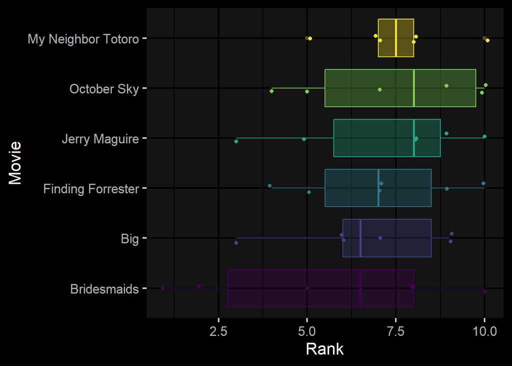

```r
movie_long_df %>%
  mutate(movie = factor(movie, levels = rev(movie_long_mean$movie))) %>%
  ggplot(
    aes(
      x = movie,
      y = vote,
      color = movie,
      fill = movie
    )
  ) +
  geom_boxplot(alpha = 0.3) +
  geom_jitter(width = 0.1,
              height = 0.1) +
  scale_color_viridis_d() +
  scale_fill_viridis_d() +
  dark_theme_gray(base_size = 16) +
  labs(x = "Movie",
       y = "Rank") +
  coord_flip() +
  guides(fill = FALSE,
         color = FALSE)
```

#### Ridgeline Plot

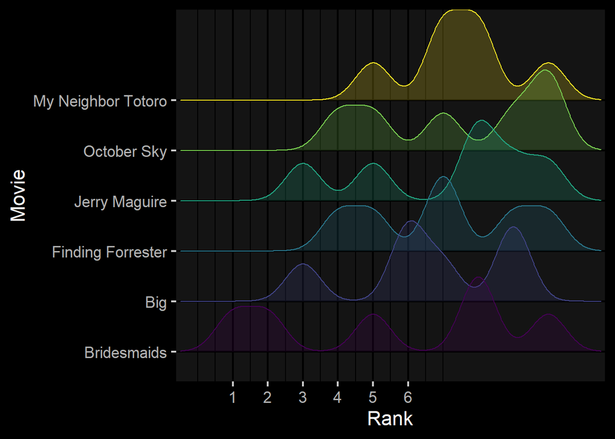

```r
movie_long_df %>%
  mutate(movie = factor(movie, levels = rev(movie_long_mean$movie))) %>%
  ggplot(aes(y = movie, x = vote,
             color = movie,
             fill = movie)) +
  geom_density_ridges(bandwidth = 0.5, alpha = 0.2) +
  theme_ridges() +
  dark_theme_gray(base_size = 16) +
  labs(x = "Rank",
       y = "Movie") +
  guides(fill = FALSE,
         color = FALSE) +
  scale_color_viridis_d() +
  scale_fill_viridis_d() +
  scale_x_continuous(
    expand = c(0.01, 0),
    breaks = 1:length(unique(movie_long_df$movie))
  )
```

#### Density Curve

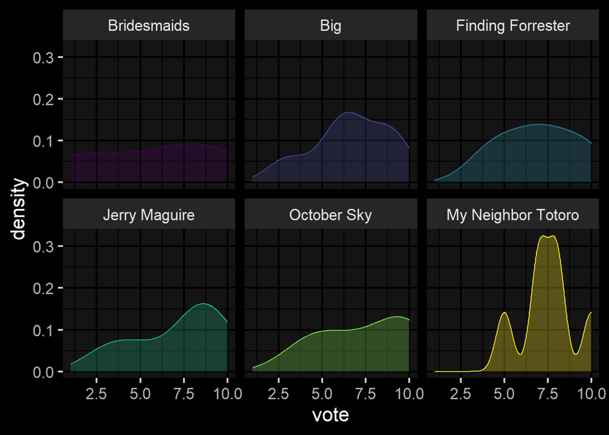

### Controversial

What about the highest variance?

| movie | stan_dev |
| --- | --- |
| Bridesmaids | 3.614784 |
| Jerry Maguire | 2.639444 |
| October Sky | 2.588436 |
| Finding Forrester | 2.280351 |
| Big | 2.250926 |
| My Neighbor Totoro | 1.643168 |

## Watchers

Who are the film critics, whom all others follow? Who are the freaks?

We define 2 measures of watching preference, *mean absolute difference* and the *sum of squared differences*.

#### Mean Absolute Difference

We take the average distance of each cinema-goer’s rank for a given movie from that movie’s sample mean.

| Timestamp | mean_abs_diff |
| --- | --- |
| 11/8/2020 15:38:19 | 1.305556 |
| 11/8/2020 15:47:42 | 1.638889 |
| 11/8/2020 16:30:39 | 1.694444 |
| 11/8/2020 19:12:32 | 2.138889 |
| 11/8/2020 15:43:32 | 2.361111 |
| 11/8/2020 15:46:48 | 2.638889 |

On down the list, you have the lesser movie critics, with indisputably irrational preferences. Timestamps are provided to keep responses anonymous, but you know who you are…

#### Sum of Squared Differences

According to some, the sum of squared differences is a demonstrably poorer metric than mean absolute deviation, but I indulge the reader.

| Timestamp | sum_sqrd_diff |
| --- | --- |
| 11/8/2020 15:38:19 | 15.75000 |
| 11/8/2020 16:30:39 | 23.08333 |
| 11/8/2020 15:47:42 | 24.08333 |
| 11/8/2020 19:12:32 | 35.41667 |
| 11/8/2020 15:43:32 | 49.41667 |
| 11/8/2020 15:46:48 | 50.75000 |